# Roane

Topics that will be discussed in this summary report for Roane County are

- Demographic Characteristics
  - Population growth from 1970 to 2020;
  - population density
  - sex, race, and age
  - educational level of the adult population
  - housing characteristics in terms of age of the housing stock and type of tenure
- Economic Characteristics
  - family income, household income, per capita income,
  - poverty status of families;
  - employment classification according to industry;
  - labor force by place of work and commuting patterns;

For more details on the data used, please see the Data Description tab.

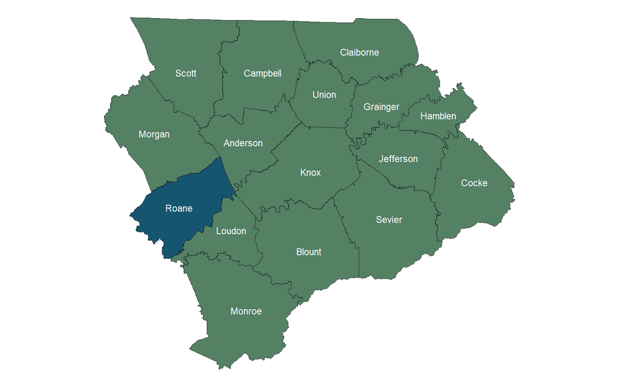

**Population and Growth**

| Place | 1970 | 1980 | 1990 | 2000 | 2010 | 2020 | Change 1970-1980 | Change 1980-1990 | Change 1990-2000 | Change 2000-2010 | Change 2010-2020 |
| --- | --- | --- | --- | --- | --- | --- | --- | --- | --- | --- | --- |
| Roane County | 38881 | 48425 | 47227 | 51910 | 54181 | 53404 | 9544 | -1198 | 4683 | 2271 | -777 |
| Harriman | 8734 | 8303 | 7119 | 6744 | 6350 | 5892 | -431 | -1184 | -375 | -394 | -458 |
| Kingston | 4142 | 4441 | 4552 | 5264 | 5934 | 5953 | 299 | 111 | 712 | 670 | 19 |
| Rockwood | 5259 | 5767 | 5348 | 5774 | 5562 | 5444 | 508 | -419 | 426 | -212 | -118 |

[interactive chart not shown]

IPUMS NHGIS, University of Minnesota, www.nhgis.org

**Population Density**

| Place | Area | Population Density |
| --- | --- | --- |
| Roane County | 394.930577688416 | 135.2237659402852 |
| Harriman | 10.69244182256778 | 551.0434471164646 |
| Kingston | 7.964684609802007 | 747.424448254202 |
| Rockwood | 8.04313564227037 | 676.8504526256254 |

[interactive chart not shown]

source: U. S. Census Bureau *Decennial Census: Redistricting Data (PL 94-171)*, 2020, accessed June 2, 2026, http://api.census.gov/data/2020/dec/pl.

**Population Descriptions**

| Place | Year | Race Category | Number of People | Percentage of People |
| --- | --- | --- | --- | --- |
| Roane County | 2020 | Black | 1303 | 0.01843181078748957 |
| Roane County | 2020 | Other | 3638 | 0.05146195521480203 |
| Roane County | 2020 | White | 48463 | 0.6855417085142801 |
| Harriman | 2020 | Black | 352 | 0.004979276590327189 |
| Harriman | 2020 | Other | 478 | 0.006761631278910218 |
| Harriman | 2020 | White | 5062 | 0.07160539233021657 |
| Kingston | 2020 | Black | 203 | 0.002871571442717101 |
| Kingston | 2020 | Other | 400 | 0.005658268852644533 |
| Kingston | 2020 | White | 5350 | 0.07567934590412063 |
| Rockwood | 2020 | Black | 227 | 0.003211067573875773 |

[output cut: 2 more lines]

| Place | Sex | Age Range | Year | Number of People | Percentage of People |
| --- | --- | --- | --- | --- | --- |
| Roane County | Female | 10 to 14 years | 2020 | 1253 | 0.01768100808556874 |
| Roane County | Female | 15 to 19 years | 2020 | 1533 | 0.02163207134491371 |
| Roane County | Female | 20 to 24 years | 2020 | 1361 | 0.01920498962845894 |
| Roane County | Female | 25 to 29 years | 2020 | 1478 | 0.02085596963325666 |
| Roane County | Female | 30 to 34 years | 2020 | 1336 | 0.01885221612316029 |
| Roane County | Female | 35 to 39 years | 2020 | 1449 | 0.02044675236711022 |
| Roane County | Female | 40 to 44 years | 2020 | 1356 | 0.01913443492739921 |
| Roane County | Female | 45 to 49 years | 2020 | 1783 | 0.02515980639790029 |
| Roane County | Female | 5 to 9 years | 2020 | 1510 | 0.02130751972003895 |
| Roane County | Female | 50 to 54 years | 2020 | 2037 | 0.02874398521173466 |

[output cut: 134 more lines]

[interactive chart not shown]

source: U. S. Census Bureau *Decennial Census: Redistricting Data (PL 94-171)*, 2020, accessed June 2, 2026, http://api.census.gov/data/2020/dec/pl.

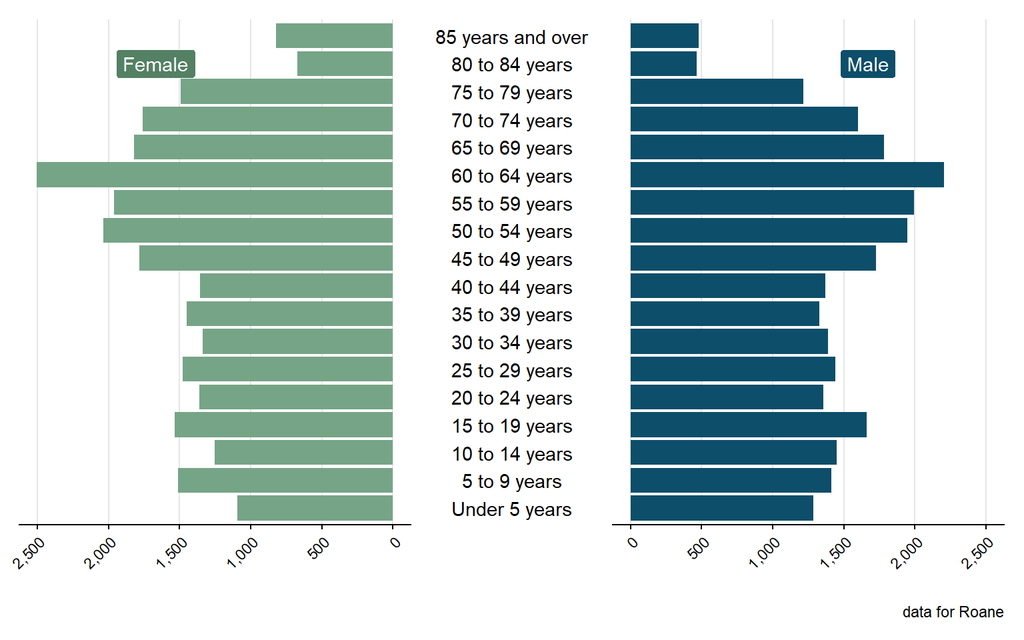

source: U. S. Census Bureau *American Community Survey 5-Year Estimates: Comparison Profiles 5-Year*, 2020, accessed June 2, 2026, http://api.census.gov/data/2020/acs/acs5.

**Education**

| Place | Level of Education | Year | Number of People | Percentage of People |
| --- | --- | --- | --- | --- |
| Roane County | 9th to 12th Grade, No Diploma | 2010 | 3530 | 0.06786503893107758 |
| Roane County | Associate's degree | 2010 | 2840 | 0.05459963472075363 |
| Roane County | Bachelor's degree | 2010 | 4071 | 0.07826588484091128 |
| Roane County | Graduate or Professional Degree | 2010 | 2445 | 0.0470056714409305 |
| Roane County | Less Than 9th Grade | 2010 | 3046 | 0.05856003076035759 |
| Roane County | Some College, No Degree | 2010 | 8347 | 0.1604729404979333 |
| Roane County | Total | 2010 | 39024 | 0.7502451215995386 |
| Roane County | 9th to 12th Grade, No Diploma | 2020 | 1917 | 0.03668478260869566 |
| Roane County | Associate's degree | 2020 | 3432 | 0.06567666870789957 |
| Roane County | Bachelor's degree | 2020 | 4497 | 0.08605710349050827 |

[output cut: 46 more lines]

[interactive chart not shown]

source: U. S. Census Bureau *American Community Survey 5-Year Estimates: Comparison Profiles 5-Year*, 2020, accessed June 2, 2026, http://api.census.gov/data/2020/acs/acs5.

**Housing Units by Year of Construction**

| Place | Year | 1939 or earlier | 1940-1959 | 1960-1979 | 1980 to 1989 | 1990 to 1999 | 2000 to 2004 | 2005 or later | 2000 to 2009 | 2010 or later | Total |
| --- | --- | --- | --- | --- | --- | --- | --- | --- | --- | --- | --- |
| Roane County | 2010 | 2130 | 4550 | 7949 | 3684 | 3991 | 1999 | 1111 |  |  | 25414 |
| Roane County | 2020 | 1991 | 4625 | 7087 | 3644 | 3775 |  |  | 3730 | 838 | 25690 |
| Harriman | 2010 | 895 | 1156 | 1062 | 359 | 131 | 15 | 20 |  |  | 3638 |
| Kingston | 2010 | 46 | 828 | 649 | 286 | 410 | 149 | 205 |  |  | 2573 |
| Rockwood | 2010 | 450 | 724 | 690 | 117 | 315 | 183 | 26 |  |  | 2505 |
| Harriman | 2020 | 574 | 958 | 1175 | 209 | 225 |  |  | 103 | 35 | 3279 |
| Kingston | 2020 | 72 | 1104 | 513 | 450 | 448 |  |  | 303 | 52 | 2942 |
| Rockwood | 2020 | 658 | 673 | 607 | 251 | 159 |  |  | 127 | 77 | 2552 |

[interactive chart not shown]

source: U. S. Census Bureau *Decennial Census: Redistricting Data (PL 94-171)*, 2020, accessed June 2, 2026, http://api.census.gov/data/2020/dec/pl.

**Housing Units by Type of Tenure**

| Place | Year | Own | Rent | Total |
| --- | --- | --- | --- | --- |
| Roane County | 2010 | 17367 | 5205 | 22572 |
| Roane County | 2020 | 16337 | 5259 | 21596 |
| Harriman | 2010 | 1637 | 1254 | 2891 |
| Kingston | 2010 | 1791 | 668 | 2459 |
| Rockwood | 2010 | 1600 | 812 | 2412 |
| Harriman | 2020 | 1627 | 1083 | 2710 |
| Kingston | 2020 | 1568 | 953 | 2521 |
| Rockwood | 2020 | 1194 | 908 | 2102 |

[interactive chart not shown]

source: U. S. Census Bureau *Decennial Census: Redistricting Data (PL 94-171)*, 2020, accessed June 2, 2026, http://api.census.gov/data/2020/dec/pl.

**Income Comparison**

| Place | Year | Median Family Income | Median Household Income | Per Capita Income |
| --- | --- | --- | --- | --- |
| Roane County | 2020 | 72137 | 55578 | 32067 |
| Harriman | 2020 | 53991 | 36487 | 26496 |
| Kingston | 2020 | 71328 | 48179 | 28465 |
| Rockwood | 2020 | 44771 | 35607 | 24730 |

[interactive chart not shown]

source: U. S. Census Bureau *Decennial Census: Redistricting Data (PL 94-171)*, 2020, accessed June 2, 2026, http://api.census.gov/data/2020/dec/pl.

**Povery Status**

| Place | Year | Above Poverty | Below Poverty |
| --- | --- | --- | --- |
| Roane County | 2020 | 13298 | 1309 |
| Harriman | 2020 | 1500 | 106 |
| Kingston | 2020 | 1304 | 42 |
| Rockwood | 2020 | 1042 | 149 |

[interactive chart not shown]

source: U. S. Census Bureau *American Community Survey 5-Year Estimates: Comparison Profiles 5-Year*, 2020, accessed June 2, 2026, http://api.census.gov/data/2020/acs/acs5.

**Poverty Status by Family Type**

| Place | Poverty Status | Family Type | Number of Families | Year | Percentage of Families |
| --- | --- | --- | --- | --- | --- |
| Roane County | Above Poverty | All Families | 13298 | 2020 | 0.7092266666666667 |
| Roane County | Above Poverty | Female Householder | 1688 | 2020 | 0.09002666666666667 |
| Roane County | Above Poverty | Female Householder with related children | 934 | 2020 | 0.04981333333333333 |
| Roane County | Below Poverty | All Families | 1309 | 2020 | 0.06981333333333334 |
| Roane County | Below Poverty | Female Householder | 337 | 2020 | 0.01797333333333333 |
| Roane County | Below Poverty | Female Householder with related children | 208 | 2020 | 0.01109333333333333 |
| Harriman | Above Poverty | All Families | 1500 | 2020 | 0.08 |
| Harriman | Above Poverty | Female Householder | 293 | 2020 | 0.01562666666666667 |
| Harriman | Above Poverty | Female Householder with related children | 82 | 2020 | 0.004373333333333333 |
| Harriman | Below Poverty | All Families | 106 | 2020 | 0.005653333333333333 |

[output cut: 14 more lines]

[interactive chart not shown]

source: U. S. Census Bureau *American Community Survey 5-Year Estimates: Comparison Profiles 5-Year*, 2020, accessed June 2, 2026, http://api.census.gov/data/2020/acs/acs5.

**Employment by Industry**

| Place | Industry | Year | Number of Jobs | Percentage of Jobs |
| --- | --- | --- | --- | --- |
| Harriman | Arts, Entertainment, And Recreation, And Accommodation And Food Services | 2010 | 248 | 0.1127272727272727 |
| Harriman | Arts, Entertainment, And Recreation, And Accommodation And Food Services | 2020 | 135 | 0.04635989010989011 |
| Harriman | Educational Services, And Health Care And Social Assistance | 2010 | 549 | 0.2495454545454545 |
| Harriman | Educational Services, And Health Care And Social Assistance | 2020 | 645 | 0.2214972527472527 |
| Harriman | Manufacturing | 2010 | 340 | 0.1545454545454545 |
| Harriman | Manufacturing | 2020 | 274 | 0.09409340659340659 |
| Harriman | Other Industries | 2010 | 823 | 0.3740909090909091 |
| Harriman | Other Industries | 2020 | 792 | 0.271978021978022 |
| Harriman | Professional, Scientific, And Management, And Administrative, And Waste Management Services | 2020 | 697 | 0.2570058997050148 |
| Harriman | Retail Trade | 2010 | 240 | 0.1090909090909091 |

[output cut: 34 more lines]

[interactive chart not shown]

source: U. S. Census Bureau *American Community Survey 5-Year Estimates: Comparison Profiles 5-Year*, 2020, accessed June 2, 2026, http://api.census.gov/data/2020/acs/acs5.

**Employment by Industry (Historical)**

| Place | Year | Industry | Number of Jobs | Percentage of Jobs |
| --- | --- | --- | --- | --- |
| Harriman | 2010 | Agriculture, Forestry, Fishing And Hunting, And Mining | 0 | 0 |
| Harriman | 2010 | Construction | 75 | 0.002540994714730994 |
| Harriman | 2010 | Manufacturing | 340 | 0.01151917604011384 |
| Harriman | 2010 | Other | 194 | 0.006572706328770836 |
| Harriman | 2010 | Professional Services | 1108 | 0.03753896191895921 |
| Harriman | 2010 | Public Administration | 127 | 0.004302751050277815 |
| Harriman | 2010 | Trade, Finance, Insurance &amp; Real Estate | 356 | 0.01206125491258978 |
| Harriman | 2020 | Agriculture, Forestry, Fishing And Hunting, And Mining | 72 | 0.002341311134235172 |
| Harriman | 2020 | Construction | 144 | 0.004682622268470343 |
| Harriman | 2020 | Manufacturing | 274 | 0.008909989594172737 |

[output cut: 46 more lines]

**Labor Force by Place of Work**

| Place | Year | Work Out Of State | Work Out of County of Residence | Work in County of Residence |
| --- | --- | --- | --- | --- |
| Roane County | 2020 | 335 | 11500 | 10505 |
| Harriman | 2020 | 0 | 1234 | 1424 |
| Kingston | 2020 | 0 | 1700 | 1212 |
| Rockwood | 2020 | 16 | 781 | 1332 |

[interactive chart not shown]

source: U. S. Census Bureau *American Community Survey 5-Year Estimates: Comparison Profiles 5-Year*, 2020, accessed June 2, 2026, http://api.census.gov/data/2020/acs/acs5.

**Commuting Patterns**

| Home County | Year | Number of Jobs | Percentage of Jobs |
| --- | --- | --- | --- |
| Roane | 2010 | 5426 | 0.238936104628121 |
| Roane | 2020 | 5094 | 0.2243163503456779 |
| Knox | 2020 | 1289 | 0.05676163635562993 |
| Knox | 2010 | 996 | 0.04385926284732925 |
| Anderson | 2020 | 807 | 0.03553657140340834 |
| Anderson | 2010 | 580 | 0.02554053458981021 |
| Loudon | 2020 | 393 | 0.01730591395481967 |
| Loudon | 2010 | 289 | 0.01272623189043991 |
| Blount | 2020 | 254 | 0.01118499273415826 |
| Blount | 2010 | 197 | 0.008674974679642433 |

[output cut: 3 more lines]

| Work County | Year | Number of Jobs | Percentage of Jobs |
| --- | --- | --- | --- |
| Roane | 2010 | 5426 | 0.238936104628121 |
| Roane | 2020 | 5094 | 0.2243163503456779 |
| Knox | 2020 | 5001 | 0.2202210577304153 |
| Anderson | 2010 | 4641 | 0.2043683121229468 |
| Anderson | 2020 | 4471 | 0.1968822933638645 |
| Knox | 2010 | 4440 | 0.1955171958254437 |
| Cumberland | 2020 | 341 | 0.01501607292262979 |
| Morgan | 2020 | 256 | 0.01127306354308864 |
| Cumberland | 2010 | 197 | 0.008674974679642433 |
| Morgan | 2010 | 154 | 0.006781452287639262 |

[output cut: 3 more lines]

[interactive chart not shown]

source: U. S. Census Bureau *Tn_od_main_JT00_2020*, LEHD Origin-Destination Employment Statistics, 8.3, 2020, accessed June 2, 2026, https://lehd.ces.census.gov/data/lodes/.

## References

Bureau, U. S. Census. *American Community Survey 5-Year Estimates: Comparison Profiles 5-Year*. 2020. Accessed June 2, 2026. http://api.census.gov/data/2020/acs/acs5.

Bureau, U. S. Census. *Decennial Census: Redistricting Data (PL 94-171)*. 2020. Accessed June 2, 2026. http://api.census.gov/data/2020/dec/pl.

Bureau, U. S. Census. *Tn_od_main_JT00_2020*. LEHD Origin-Destination Employment Statistics, 8.3. 2020. Accessed June 2, 2026. https://lehd.ces.census.gov/data/lodes/.